# Modeling Weight Lifting Exercises in Human Activity Recognition

Sergio Contador

March 2017

## Introduction

Using devices such as Jawbone Up, Nike FuelBand, and Fitbit it is now possible to collect a large amount of data about personal activity relatively inexpensively. These type of devices are part of the quantified self movement – a group of enthusiasts who take measurements about themselves regularly to improve their health, to find patterns in their behavior, or because they are tech geeks. One thing that people regularly do is quantify how much of a particular activity they do, but they rarely quantify how well they do it.

The goal of this project (the course project on the Practical Machine Learning Course from Coursera) is to predict the manner in which they did the exercise. This is the **classe** variable in the training set. We use any of the other variables in dataset to predict with.

## Experiment

The exercises were performed by six male participants aged between 20-28 years, with little weight lifting experience. The participants were asked to perform one set of 10 repetitions of the Unilateral Dumbbell Biceps Curl in five different fashions (the **classe** variable): exactly according to the specification (Class **A**), throwing the elbows to the front (Class **B**), lifting the dumbbell only halfway** (Class **C**), lowering the dumbbell only halfway (Class **D**) and throwing the hips to the front (Class **E**).

The participants wearing on the body accelerometers to take measures on 4 parts: belt, forearm, arm, and dumbell. There were another sensor on the dumbbell.

You can see the on-body-sensing-schema [here](http://groupware.les.inf.puc-rio.br/static/WLE/on-body-sensing-schema.png).

## Dataset

We work with the WLE dataset (read more [here](http://groupware.les.inf.puc-rio.br/har#ixzz4adw24dRG)). You can download the WLE dataset [here](http://groupware.les.inf.puc-rio.br/har).

The training data for this project are available [here](https://d396qusza40orc.cloudfront.net/predmachlearn/pml-training.csv). The test data for this project are available [here](https://d396qusza40orc.cloudfront.net/predmachlearn/pml-testing.csv).

## Data Processing

We transform train dataset into two datasets: train dataset for train phase and test dataset for test phase. Then, we use test dataset for evaluation phase.

```r
#########################################################
# Author: Sergio Contador
# Date: March 2017
# Title: Practical Machine Learninig Course: Course Project
#########################################################


# Load libraries required.
suppressMessages(library(caret))
library(rpart)
library(rpart.plot)
suppressMessages(library(randomForest))
library(corrplot)


# Load datasets.
# Create dir principal
dir.principal <- paste(getwd(), sep = "")


# Load Data
dir <- paste(dir.principal, "/Data/WearableComputing_weight_lifting_exercises_biceps_curl_variations.csv", sep = "")
dataRaw <- read.csv(dir)

dir <- paste(dir.principal, "/Data/pml-training.csv", sep = "")
dataTrainRaw <- read.csv(dir, row.names = NULL)

dir <- paste(dir.principal, "/Data/pml-testing.csv", sep = "")
dataValidateRaw <- read.csv(dir)


# filter columns on: belt, forearm, arm, dumbell
position <- grepl("belt|foreman|arm|dumbell", names(dataTrainRaw))
dataTrain <- dataTrainRaw[, position]
dataValidate <- dataValidateRaw[, position]


# Clean NA values
dataTrain <- dataTrain[, colSums(is.na(dataTrain)) == 0]
dataValidate <- dataValidate[, colSums(is.na(dataValidate)) == 0]


# Clean data having the train and test data with same variables
position <- intersect(names(dataTrain), names(dataValidate))
dataTrain <- dataTrain[position]
dataValidate <- dataValidate[position]

dataTrain$classe <- as.factor(as.character(dataTrainRaw$classe))
dataValidate$problem_id <- dataValidateRaw$problem_id


# Data Slicing for Cross Validation
set.seed(1234) # For reproducibile purpose
position <- createDataPartition(dataTrain$classe, p = 0.75, list = FALSE)
dataTest <- dataTrain[-position, ]
dataTrain <- dataTrain[position, ]


# Summary full dataset.
dim(dataRaw)
```

```
## [1] 39242   159
```

```r
# Summary train data for train phase.
dim(dataTrain)
```

```
## [1] 14718    40
```

```r
names(dataTrain)
```

```
##  [1] "roll_belt"           "pitch_belt"          "yaw_belt"
##  [4] "total_accel_belt"    "gyros_belt_x"        "gyros_belt_y"
##  [7] "gyros_belt_z"        "accel_belt_x"        "accel_belt_y"
## [10] "accel_belt_z"        "magnet_belt_x"       "magnet_belt_y"
## [13] "magnet_belt_z"       "roll_arm"            "pitch_arm"
## [16] "yaw_arm"             "total_accel_arm"     "gyros_arm_x"
## [19] "gyros_arm_y"         "gyros_arm_z"         "accel_arm_x"
## [22] "accel_arm_y"         "accel_arm_z"         "magnet_arm_x"
## [25] "magnet_arm_y"        "magnet_arm_z"        "roll_forearm"
## [28] "pitch_forearm"       "yaw_forearm"         "total_accel_forearm"
## [31] "gyros_forearm_x"     "gyros_forearm_y"     "gyros_forearm_z"
## [34] "accel_forearm_x"     "accel_forearm_y"     "accel_forearm_z"
## [37] "magnet_forearm_x"    "magnet_forearm_y"    "magnet_forearm_z"
## [40] "classe"
```

```r
# Summary train data for test phase.
dim(dataTest)
```

```
## [1] 4904   40
```

```r
names(dataTest)
```

```
##  [1] "roll_belt"           "pitch_belt"          "yaw_belt"
##  [4] "total_accel_belt"    "gyros_belt_x"        "gyros_belt_y"
##  [7] "gyros_belt_z"        "accel_belt_x"        "accel_belt_y"
## [10] "accel_belt_z"        "magnet_belt_x"       "magnet_belt_y"
## [13] "magnet_belt_z"       "roll_arm"            "pitch_arm"
## [16] "yaw_arm"             "total_accel_arm"     "gyros_arm_x"
## [19] "gyros_arm_y"         "gyros_arm_z"         "accel_arm_x"
## [22] "accel_arm_y"         "accel_arm_z"         "magnet_arm_x"
## [25] "magnet_arm_y"        "magnet_arm_z"        "roll_forearm"
## [28] "pitch_forearm"       "yaw_forearm"         "total_accel_forearm"
## [31] "gyros_forearm_x"     "gyros_forearm_y"     "gyros_forearm_z"
## [34] "accel_forearm_x"     "accel_forearm_y"     "accel_forearm_z"
## [37] "magnet_forearm_x"    "magnet_forearm_y"    "magnet_forearm_z"
## [40] "classe"
```

```r
# Summary test data for evaluate phase.
dim(dataValidate)
```

```
## [1] 20 40
```

```r
names(dataValidate)
```

```
##  [1] "roll_belt"           "pitch_belt"          "yaw_belt"
##  [4] "total_accel_belt"    "gyros_belt_x"        "gyros_belt_y"
##  [7] "gyros_belt_z"        "accel_belt_x"        "accel_belt_y"
## [10] "accel_belt_z"        "magnet_belt_x"       "magnet_belt_y"
## [13] "magnet_belt_z"       "roll_arm"            "pitch_arm"
## [16] "yaw_arm"             "total_accel_arm"     "gyros_arm_x"
## [19] "gyros_arm_y"         "gyros_arm_z"         "accel_arm_x"
## [22] "accel_arm_y"         "accel_arm_z"         "magnet_arm_x"
## [25] "magnet_arm_y"        "magnet_arm_z"        "roll_forearm"
## [28] "pitch_forearm"       "yaw_forearm"         "total_accel_forearm"
## [31] "gyros_forearm_x"     "gyros_forearm_y"     "gyros_forearm_z"
## [34] "accel_forearm_x"     "accel_forearm_y"     "accel_forearm_z"
## [37] "magnet_forearm_x"    "magnet_forearm_y"    "magnet_forearm_z"
## [40] "problem_id"
```

## Data Exploring

First, we plot density function of classe distributed along the participants. Then, we wrapper for lattice plotting of predictor variables. Finally, we look at the correlations between predictor variables ploting the correlation matrix.

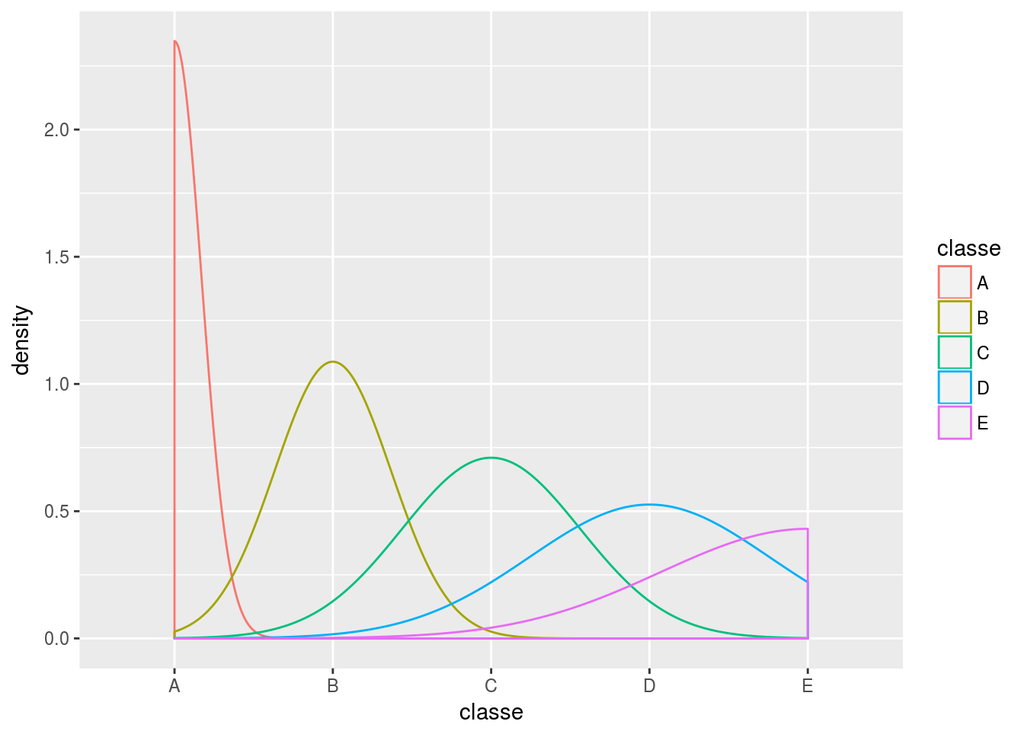

```r
# Explorationg Data
# Plot density of classe
qplot(classe, data = dataTrain, colour = classe, geom = "density")
```

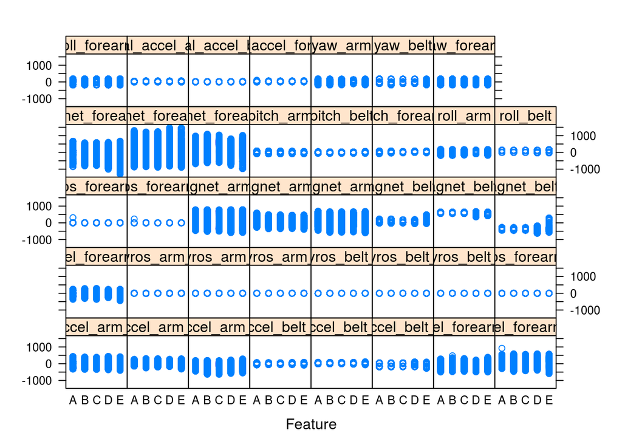

```r
# Plot the relationship between features and outcome.
# From the plot below, each features has relatively the same distribution among the 5 outcome levels (A, B, C, D, E).
featurePlot(dataTrain[, - dim(dataTrain)[2]], dataTrain[, "classe"], "strip")
```

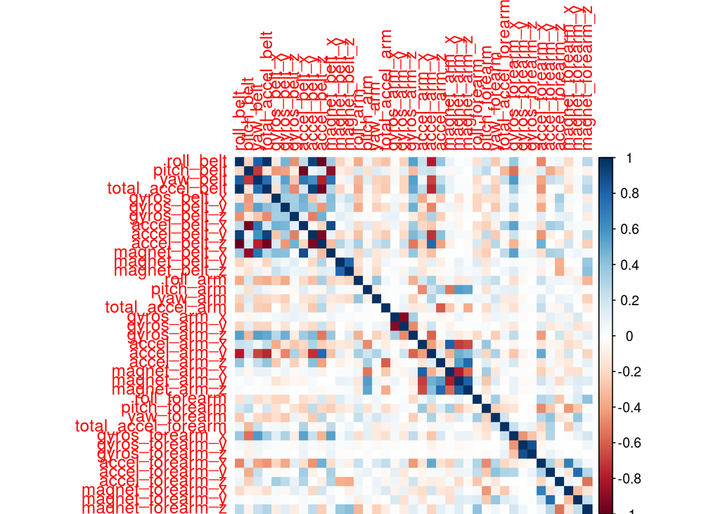

```r
# Plot correlation matrix
correlation <- cor(dataTrain[, - dim(dataTrain)[2]])
corrplot(correlation, method = "color")
```

There are some correlations between variables measured on belt, arm and foreman, but the correlations isn’t enough to consider perform further proccesing to get a subset of variables more uncorrelated (A good set of features is when they are highly uncorrelated).

## Data Modeling

We use 6-fold cross validation when applying the algorithm.

```r
# # Less than 7 min
n <- 500 #
ncv <- 6
control <- trainControl(method = "cv", number = ncv)
t <- system.time(model <- train(

        classe ~ .,
        data = dataTrain[, -1],
        method = "rf",
        trControl = control,
        ntree = n)

)
paste("Ejecution Time:", round(t[3] / 60, digits = 2), "[min]")
```

```
## [1] "Ejecution Time: 8.89 [min]"
```

```r
model
```

```
## Random Forest
##
## 14718 samples
##    38 predictors
##     5 classes: 'A', 'B', 'C', 'D', 'E'
##
## No pre-processing
## Resampling: Cross-Validated (6 fold)
## Summary of sample sizes: 12265, 12265, 12264, 12264, 12266, 12266, ...
## Resampling results across tuning parameters:
##
##   mtry  Accuracy   Kappa
##    2    0.9883137  0.9852157
##   20    0.9886535  0.9856464
##   38    0.9829462  0.9784278
##
## Accuracy was used to select the optimal model using  the largest value.
## The final value used for the model was mtry = 20.
```

## Data Prediction

```r
# Prediction
prediction <- predict(model, dataTest)
confusion <- confusionMatrix(dataTest$classe, prediction)
confusion
```

```
## Confusion Matrix and Statistics
##
##           Reference
## Prediction    A    B    C    D    E
##          A 1395    0    0    0    0
##          B    3  938    8    0    0
##          C    0   19  829    7    0
##          D    0    1   10  793    0
##          E    0    0    0    0  901
##
## Overall Statistics
##
##                Accuracy : 0.9902
##                  95% CI : (0.987, 0.9928)
##     No Information Rate : 0.2851
##     P-Value [Acc > NIR] : < 2.2e-16
##
##                   Kappa : 0.9876
##  Mcnemar's Test P-Value : NA
##
## Statistics by Class:
##
##                      Class: A Class: B Class: C Class: D Class: E
## Sensitivity            0.9979   0.9791   0.9787   0.9912   1.0000
## Specificity            1.0000   0.9972   0.9936   0.9973   1.0000
## Pos Pred Value         1.0000   0.9884   0.9696   0.9863   1.0000
## Neg Pred Value         0.9991   0.9949   0.9956   0.9983   1.0000
## Prevalence             0.2851   0.1954   0.1727   0.1631   0.1837
## Detection Rate         0.2845   0.1913   0.1690   0.1617   0.1837
## Detection Prevalence   0.2845   0.1935   0.1743   0.1639   0.1837
## Balanced Accuracy      0.9989   0.9882   0.9862   0.9943   1.0000
```

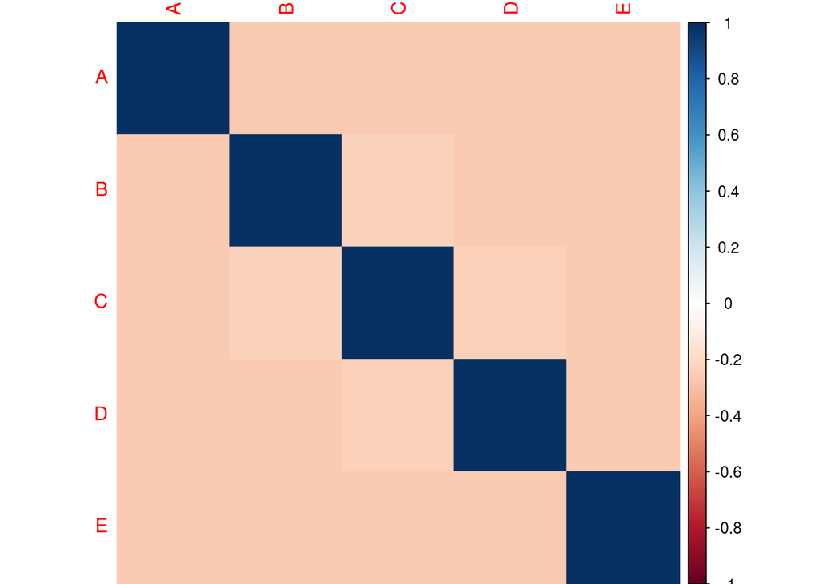

```r
# Plot correlation matrix of confusion
correlation <- cor(as.matrix(confusion))
corrplot(correlation, method = "color")
```

### Model Accuracy and Error Sample

```r
# Accuracy and Sample Error of the model
accuracy <- postResample(prediction, dataTest$classe)


# out-of-sample error of the model
error <- 1 - as.numeric(confusionMatrix(dataTest$classe, prediction)$overall[1])


# Print results
paste(paste("Accuracy:", round(accuracy[1], digits = 4)),
      paste("Error:", round(error, digits = 4)), sep = "    ")
```

```
## [1] "Accuracy: 0.9902    Error: 0.0098"
```

The error is 0.98%. So, expected error less than 1% is enough to consider our model a good model.

### Prediction

We predict 20 different test cases.

```r
# Predicting
result <- predict(model, dataValidate)
as.character(result)
```

```
##  [1] "B" "A" "B" "A" "A" "E" "D" "B" "A" "A" "B" "C" "B" "A" "E" "E" "A"
## [18] "B" "B" "B"
```

## Conclusions

We used WLE dataset for HAR of weight lifting exercises and divided data into three datasets.

We plot correlation matrix and we observed that there are some correlations between variables measured on belt, arm and foreman, but the correlations isn’t enough to consider perform further proccesing.

We selected RFA to model the data. We used 6-fold cross validation when applying the algorithm. We tested the model with the test dataset and the sample error is 0.98%. So, expected error less than 1% is enough to consider our model a good model.

We predicted the classe for 20 different cases obtaining next predictions: 35% of class A, 40% of class B, 5% of class C, 5% of class D and 15% of class E.